# Prediciendo el número de hijos de los hogares colombianos

Informe

# Introducción

En la actualidad, debido a la globalización es importante para las empresas conocer a sus clientes, la tecnología, sin duda ha permitido recaudar volúmenes enormes de información, sin embargo, en muchas ocasiones precisamente la información requerida por una empresa es difícil de obtener o representa información sensible para los usuarios, ya que invade su privacidad. No obstante, con los avances en analítica se han creado herramientas para lograr obtener la información necesaria de los usuarios sin invadir su intimidad y está ha podido utilizarse para estimar valores sobre el resto de la población, aun sin tener que preguntar directamente sobre la misma.

Entre los datos que en algunos contextos pueden ser censurados u omitidos está el número de hijos en un hogar, lo que hace que sea una variable de la que no se dispone directamente; por lo tanto el problema en particular en el que se está interesado es la predicción del número de hijos en base a las características de los hogares colombianos.

Se decidió abordar este problema como un problema de clasificación (aprendizaje supervisado). Para esto se tuvo en cuenta los siguiente:

Se realizó una buena investigación y contextualización del conjunto de datos que fueron obtenidos de la ECV realizada por el DANE en el año 2019, mediante este se tuvo la oportunidad de establecer el número de hijos, a partir de, la combinación de algunas variables presentes en un conjunto de datos particular abordado en la encuesta, además de seleccionar las variables más relevantes para realizar un análisis y la modelación.

Se procedió a la selección de variables, las cuales posteriormente fueron unidas mediante indicadores de hogares. Este procedimiento fue realizado de manera muy cuidadosa para no obtener información incorrecta, después de este paso se llegó a una base de datos con las variables que los investigadores consideraron de interés.

Previo a lo anterior, se procedió a realizar un análisis descriptivo sobre el conjunto de datos, que ayudaran a una mejor comprensión de las variables y a seleccionar cuales de estas eran más relevantes para predecir el número de hijos, se realizaron gráficos y demás análisis.

Como paso siguiente se usaron técnicas estadísticas para la selección de variables mediante la formulación de modelos, los cuales en su mayoría coincidieron con las variables seleccionadas mediante el análisis descriptivo.

Después de seleccionar las variables, se obtuvo un conjunto de datos con menos atributos, pero con el mismo número de registros, y asi se empezó a modelar el número de hijos como un problema de clasificación, donde cada nivel de la variable respuesta es una categoría.

Los modelos seleccionados fueron considerados como los más adecuados para este problema en particular y son populares en el mundo del aprendizaje estadístico. Se realizaron ajustes con cada uno y se evaluó su rendimiento mediante validación cruzada (Calculando tasas de acierto y error).

Después de ajustar varios modelos, se analizó la posibilidad de encontrar el mismo resultado con menos variables, encontrando que se obtenía la misma tasa de acierto, aunque, el número de atributos utilizados era menor; por lo tanto, se decidió nuevamente hacer una reducción del conjunto de datos, de tal manera que se obtuvieron modelos más parsimoniosos (Buenos resultados con menos variables) llegando finalmente a modelos con cinco variables.

De los modelos ajustados inicialmente se consideraron los cuatro mejores. Posteriormente estos modelos se ponen en competencia mediante distintas muestras aleatorias, divididas en conjunto de entrenamiento y validación; de tal manera, que el mejor modelo sea aquel que obtenga mejores resultados en el conjunto de validación en las diferentes muestras.

Bosques Aleatorios resultó ser el mejor después de este procedimiento, teniendo una alta tasa de aciertos. Después, se ajustó el mismo modelo con el conjunto de datos completo, con el fin de generar mejores predicciones por el hecho de contar con un mayor número de información.

Como parte final, se aplicó el modelo obtenido en una aplicación web que permite la interacción con usuarios, esto mostrará su potencial para predecir el número de hijos de un hogar colombiano según la estructura del mismo.

# Retos

- Contextualizar la base de datos.
- Seleccionar las variables.
- Construir la variable número de hijos.
- Organizar la base de datos con variables que contribuyan de manera significativa a la solución del problema.
- Encontrar modelos que se ajusten a las necesidades del conjunto de datos.
- Seleccionar una solución óptima tanto para los investigadores como para los usuarios.

# Contextualización del conjunto de datos:

El número de hijos en un hogar es una variable muy simple y poco estudiada en algunos contextos, por eso los volúmenes de datos que se encuentran en la web muchas veces no disponen de este tipo de información, pero para entidades como inmobiliarias, empresas crediticias, etc; puede serles de sumo interés, por ello, bajo trabajos de investigación se llega a la conclusión de que estas variables pueden ser deducidas a partir de otras que siguen en el mismo contexto, en este caso particular el número de hijos puede ser deducida a partir de conjuntos de datos relacionados con información acerca de los hogares del país, por lo tanto, una de las bases de datos que se considera tienen más relación con las viviendas y hogares de Colombia es la encuesta de Calidad de vida, donde la más actualizada hasta la fecha es la realizada en el año 2019.

La Encuesta de Calidad de Vida (ECV) es una investigación que realiza el DANE, con el objetivo de recoger información sobre diferentes aspectos y dimensiones del bienestar de los hogares, incluyendo aspectos como el acceso a bienes y servicios públicos, privados o comunales, salud, educación, cuidado de niños y niñas menores de 5 años, entre otros. Esta información posibilita efectuar análisis posteriores de los factores que explican los diferentes niveles de vida existentes en la población colombiana.

Por ello mediante este conjunto de datos que tiene un gran volumen, se intenta extraer aquellas variables que se consideran más representativas para intentar predecir el número de hijos que tiene cada uno de los hogares; antes de ello, se debe definir para esta investigación que es un hogar y que es el número de hijos, para realizar todos los análisis posteriores en función de esta variable (Número de hijos en el hogar).

## Definiciones importantes

### Usuario

Inmobiliarias, empresas crediticias, en las cuales el número de hijos es una información sensible, ya que esto puede suponerse como un impedimento ya sea a la hora de conseguir o rentar apartamento, o para conseguir préstamos; debido a que, se concibe que el mantenimiento de los hijos es elevado y este sube cuantos más hijos posee el prestatario, por lo que resulta más complicado para los padres de familia acceder a los mismos.

Agencias o constructoras inmobiliarias en ocasiones tienen mucha información histórica de los clientes, sobretodo de los jefes de hogar, obteniendo así información relevante de las características de un hogar. En base a estas características podemos predecir el número de hijos del mismo, esta información puede ser utilizada por dichas empresas para lanzar nuevos proyectos y ofrecer atención más personalizada a sus usuarios.

Adicionalmente, algunas empresas que facilitan el arriendo como intermediarios pueden tener políticas de arriendo como el hecho de que no se admiten hijos en los hogares, esto es común en residencias estudiantiles, entre otros.

### Hogar

Según el DANE se entiende como hogar a una persona o grupo de personas que ocupan la totalidad o parte de una vivienda y que se han asociado para compartir su lugar de descanso, alimentos y demás necesidades básicas (si se trata de hogar-unidad doméstica) . Pueden ser familiares o no entre sí.

Un hogar no puede dividirse en más de una vivienda, pero dentro de cada vivienda, puede haber más de un hogar, conformado por una o más personas con o sin vínculos de parentesco.

### Número de hijos

Se define el número de hijos de acuerdo con los hogares colombianos promedio, definidos por el DANE, en los cuales se tienen:

- Parejas con hijos.
- Una persona sola.
- Padre o madre y sus hijos.
- Parejas sin hijos.
- Hogar extenso-compuesto, definido como hogares nucleares (alguna de las opciones anteriormente mencionadas) más otros parientes.

Se muestra a continuación una imagen que ejemplifica mejor lo antes mencionado:

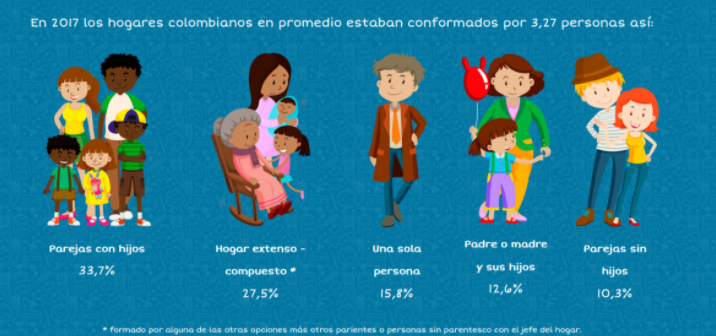

En base a esto se considera como el número de hijos, a los hijos, hijastros y nietos del jefe del hogar, sin discriminar por edad, ya que está es la forma que en general funciona mejor, en base a la mayoría de estructuras de los hogares en Colombia.

En casos generales funciona esta estructura ya que en la mayoría de hogares cuenta con padres y si estos no están presentes, los abuelos de los hijos lo están, cuando se considera que hay varios grupos familiares en una misma vivienda, como lo son por ejemplo, varios hermanos con sus respectivos hijos, estos se dividirán en diferentes hogares; ya que son varios núcleos familiares en una misma vivienda, los cuales deben ser tomados como hogares de manera independiente, por lo tanto, estructuras como estas no sesgan la elección de la variable **número de hijos**. Además, cabe aclarar que la encuesta de calidad de vida hace esta misma división, ya que en una misma vivienda se ven presentes varios hogares(siendo 5 el máximo), por lo tanto, esta variable fue seleccionada con los hijos/hijastros y nietos del jefe del hogar; en base a la estructura de la encuesta de calidad de vida y en la perspectiva de los investigadores.

# Materiales

## Variables preselecionadas

### Características y composición del hogar.

Compuesta por 46 variables de las cuales se escogieron

[output not shown]

### Condiciones de vida del hogar y tenencia de bienes (programas).

Compuesta por 8 variables de las cuales se escogió:

| Código | Nombre | Pregunta |
| --- | --- | --- |
| P784S4A3 | Num_subsidios | ¿Cuántos miembros del hogar reciben subsidios? |

### Datos de la vivienda.

Compuesta por 35 variables de las cuales se escogieron:

[output not shown]

### Educación.

Compuesta por 58 variables de las cuales se escogieron:

| Código | Nombre | Pregunta |
| --- | --- | --- |
| P8586 | Estudia | ¿El jefe del hogar actualmente estudia? (asiste al preescolar, escuela, colegio o universidad) 1 Sí 2 No |
| P8587 | Nivel_educativo | ¿Cuál es el nivel educativo más alto alcanzado por el jefe del hogar y el último año o grado aprobado en este nivel? 1 Ninguno 2 Preescolar 3 Básica Primaria (1º - 5º) 4 Básica secundaria (6º–9º) 5 Me… |

### Salud.

Compuesta por 103 variables de las cuales se escogieron:

| Código | Nombre | Pregunta |
| --- | --- | --- |
| P6090 | Afiliado | ¿El jefe del hogar está afiliado (a), es cotizante o es beneficiario (a) de alguna entidad de seguridad social en salud? (Entidad promotora de salud [EPS] o entidad promotora de salud subsidiada EPS-S… |
| P6127 | Salud_general | El estado de salud del jefe del hogar en general, es: 1 Muy bueno 2 Bueno 3 Regular 4 Malo |

### Servicios del hogar.

Compuesta por 64 variables de las cuales se escogieron:

| Código | Nombre | Pregunta |
| --- | --- | --- |
| P5666 | Gas_natural | ¿En este hogar tienen servicio de Gas Natural conectado a red pública? 1 Sí 2 No |
| P5305 | Telefonia_fija | ¿En este hogar tienen servicio telefónico fijo? 1 Sí 2 No |
| I_HOGAR | Ingresos_hogar | Ingreso Mensual Total del Hogar |

### Tenencia y financiación de la vivienda que ocupa el hogar.

Compuesta por 20 variables de las cuales se escogieron:

| Código | Nombre | Pregunta |
| --- | --- | --- |
| P5095 | Contrato_vivienda | ¿La vivienda ocupada por este hogar es? 1. Propia, totalmente pagada 2. Propia, la están pagando 3. En arriendo o subarriendo 4. Con permiso del propietario, sin pago alguno (usufructuario) 5. Posesió… |

### Uso de energéticos del hogar.

Compuesta por 45 variables de las cuales se escogieron:

| Código | Nombre | Pregunta |
| --- | --- | --- |
| P5018 | Ultimo_pago_energia | ¿Cuánto pagaron EL MES PASADO o la última vez por la electricidad consumida? |
| P5018S1 | - | ¿A cuántos meses corresponde el pago de la última vez por la electricidad consumida? |

### Variables construidas a partir de otras.

| Código | Nombre | Variables utilizadas |
| --- | --- | --- |
| P5018S | Pago_mes_energia | Esta variable fue creada dividiendo P5018/P5018S1 con el fin de obtener el pago mensual de electricidad |
| Num_integrantes | Num_integrantes | Esta variable fue creada sumando 1 unidad cada vez que el número de ORDEN cambiaba |
| Num_hijos | Num_hijos | Esta variable fue creada sumando 1 cada vez que la pregunta código P6051 toma el valor de 3 o 4 correspondiente a hijo o nieto |

# Metodología

## Preprocesamiento de los datos

### Creación de la variable número de hijos

Debido a que la variable de interés (Número de hijos) no aparece de manera explícita, se llevó a cabo un proceso de construcción de la misma. Esto fue posible gracias a algunas de las variables de la base de datos Características y composición del hogar, presente en la ECV(2019) que permiten conocer la relación de cada individuo con el jefe del hogar.

Como primer paso se realiza la lectura de las bases de datos:

```r
Caracteristicas_hogar_personas <- read.table("Caracteristicas y composicion del hogar.csv", sep = ";", header = T)
```

Debido a que la variable P6051 muestra el parentesco de los integrantes de la familia con el jefe de hogar, solo será utilizada para la creación de la variable número de hijos, es decir, no se tiene en cuenta como covariable para el ajuste de modelos:

Selección de las variables que permitiran la creación de la variable respuesta **número de hijos** a partir del conjunto de datos Caracteristicas y composición del hogar:

```r
#Selección de las variables necesarias
aux_creacion_respuesta<-Caracteristicas_hogar_personas[,c("ï..DIRECTORIO","SECUENCIA_P","P6051")]
```

Para obtener el número de hijos por hogar se filtran las filas, si tienen una relacion de hijo/hija/hijastro(a) o nieto/nieta con el jefe de hogar y se cuenta el número de hijos por hogar. Los hogares se describen con el código único de ï..DIRECTORIO, SECUENCIA_P.

El conjunto de datos presente a continuación solo contiene a los hogares con hijos:

```r
require(tidyverse)
require(dplyr)

# P6051 = 3 : Hijo/hija/hijastro(a)
# P6051 = 4 : Nieto/nieta

num_hijos <- aux_creacion_respuesta %>%
  filter(P6051 == 3 | P6051 == 4)%>% #filtro
  group_by(ï..DIRECTORIO, SECUENCIA_P)%>% # agrupando por el identificador del hogar
  count(SECUENCIA_P) # Conteo del número de hijos por hogar
```

| ï..DIRECTORIO | SECUENCIA_P | n |
| --- | --- | --- |
| 7120001 | 1 | 1 |
| 7120002 | 1 | 7 |
| 7120009 | 1 | 1 |
| 7120010 | 1 | 3 |
| 7120016 | 1 | 2 |
| 7120018 | 1 | 2 |

El número de hogares que tiene al menos un hijo es de: 59575 hogares.

A continuación, se procede a calcular el número de integrantes que pertenecen a cada hogar:

```r
require(dplyr)
num_integrantes <- Caracteristicas_hogar_personas %>%
  group_by(ï..DIRECTORIO, SECUENCIA_P) %>% # agrupación por el indicador de los hogares
  count(SECUENCIA_P) #Conteo del número de integrantes por hogar
```

| ï..DIRECTORIO | SECUENCIA_P | n |
| --- | --- | --- |
| 7120001 | 1 | 4 |
| 7120002 | 1 | 10 |
| 7120005 | 1 | 2 |
| 7120006 | 1 | 3 |
| 7120007 | 1 | 3 |
| 7120008 | 1 | 1 |

El número de hogares es 93993.

Finalmente, con la función *merge* se obtiene el número de hijos en cada hogar, uniendo las bases de datos *num_integrantes* y *num_hijos* como sigue:

- el all.x = TRUE hace que se conserven todos los identificadores de los hogares que tienen integrantes y no sólo de los que poseen hijos.

```r
num_hijos_final <- merge(num_integrantes, num_hijos, by =c("ï..DIRECTORIO","SECUENCIA_P"), all.x=TRUE) # merge de las dos bases de datos creadas anteriormente.

num_hijos_final$n.y[is.na(num_hijos_final$n.y)] <- 0 # Los datos faltantes indican que el hogar no tiene hijos

colnames(num_hijos_final) <- c("ï..DIRECTORIO","SECUENCIA_P", "Num Integrantes", "Num Hijos")
```

| ï..DIRECTORIO | SECUENCIA_P | Num Integrantes | Num Hijos |
| --- | --- | --- | --- |
| 7120001 | 1 | 4 | 1 |
| 7120002 | 1 | 10 | 7 |
| 7120005 | 1 | 2 | 0 |
| 7120006 | 1 | 3 | 0 |
| 7120007 | 1 | 3 | 0 |
| 7120008 | 1 | 1 | 0 |
| 7120009 | 1 | 2 | 1 |
| 7120010 | 1 | 5 | 3 |
| 7120013 | 1 | 4 | 0 |
| 7120016 | 1 | 3 | 2 |

### Selección de variables

Como paso siguiente se realizó de manera exhaustiva en cada una de las bases de la ECV, una preselección de covariables que a criterio de los investigadores, podrían tener alguna relación con la variable respuesta. Con la información anterior se procede a construir la base de datos para el paso siguiente.

A continuación se muestra la base que se obtuvo con las variables preseleccionadas que aparecen listadas en la contextualización de los datos:

```r
# Características del hogar

Caracteristicas_hogar_personas <- read.table("Caracteristicas y composicion del hogar.csv", sep = ";", header = T)
Caracteristicas_hogar_personas<-Caracteristicas_hogar_personas[,c("ï..DIRECTORIO","SECUENCIA_P","ORDEN","P6020", "P6040","P6051", "P5502", "P756","P6081", "P6087","P6083","P6088","P6080")]

# Condiciones de vida del hogar y tenencia de bienes (programas)

condiciones_de_vida <- read.table("Condiciones de vida del hogar y tenencia de bienes (programas).csv", sep=";", header = T)
condiciones_de_vida <- condiciones_de_vida[, c("ï..DIRECTORIO","SECUENCIA_ENCUESTA","ORDEN","P784S4A3")]

# Datos de la vivienda

Datos_vivienda <- read.table("Datos de la vivienda.csv", sep = ";", header = T)
Datos_vivienda<-Datos_vivienda[,c("ï..DIRECTORIO","SECUENCIA_P","ORDEN","CANT_HOGARES_VIVIENDA","P1070","P4015","P8520S1","P8520S1A1","P8520S5","P8520S3", "P8520S4A1")]

# Educación

Educacion<- read.table("Educacion.csv", sep = ";", header = T)
Educacion<-Educacion[,c("ï..DIRECTORIO","SECUENCIA_P","ORDEN","P8587","P8586")]

# Fuerza de trabajo

fuerza_trabajo <- read.table("Fuerza de trabajo.csv", sep=";", header = T)
fuerza_trabajo <- fuerza_trabajo[, c("ï..DIRECTORIO","SECUENCIA_P","ORDEN", "P6435")]

# Salud

Salud<- read.table("Salud.csv", sep = ";", header = T)
Salud<-Salud[,c("ï..DIRECTORIO","SECUENCIA_P","ORDEN","P6090","P6127")]

# Servicios del hogar

ServiciosDelHogar<- read.table("Servicios del hogar.csv", sep = ";", dec=",", header = T)
ServiciosDelHogar<-ServiciosDelHogar[,c("ï..DIRECTORIO","SECUENCIA_ENCUESTA","ORDEN","P5000","P5666","P5305", "I_HOGAR")]

# Tecnología e información y comunicación

tecn_inf_comunicacion <- read.table("Tecnologías de información y comunicación.csv", sep=";", header = T)
tecn_inf_comunicacion <- tecn_inf_comunicacion[, c("ï..DIRECTORIO","SECUENCIA_P","ORDEN","P769")]

# Tenencia y financiación de la vivienda que ocupa el hogar

financiacion_vivienda <- read.table("Tenencia y financiación de la vivienda que ocupa el hogar.csv", sep=";", header = T)
financiacion_vivienda <- financiacion_vivienda[,c("ï..DIRECTORIO","SECUENCIA_ENCUESTA","ORDEN","P5095")]

# Uso de energéticos del hogar

energeticos_hogar <- read.table("Uso de energéticos del hogar.csv", sep=";", header = T)
energeticos_hogar <- energeticos_hogar[,c("ï..DIRECTORIO","SECUENCIA_ENCUESTA","ORDEN", "P5018", "P5018S1")]
```

### Unión de las bases de datos:

Se creó una única base de datos con la variable de interés (Número de hijos) y las demás variables seleccionadas. Dado que las posibles variables explicativas provenían de diferentes tablas, se procedió a realizar un merge entre ellas, usando como variable de referencia la columna “Directorio” y “Secuencia” que son las dos variables que identifican a un hogar, y teniendo especial cuidado en la unión de tablas donde las preguntas pueden ser por vivienda, hogar o integrantes y se debía llevar a una misma estructura de hogares.

```r
# Merge de la base de datos de caracteristicas del hogar con condiciones de vida

# SECUENCIA_P Y SECUENCIA_ENCUESTA son las mismas variables pero toman un nombre distinto en ambas bases de datos.
Base1 <- merge(Caracteristicas_hogar_personas, condiciones_de_vida, by.x = c("ï..DIRECTORIO","SECUENCIA_P"), by.y = c("ï..DIRECTORIO","SECUENCIA_ENCUESTA"), all.x =TRUE)

# Merge de Base1 con datos vivienda

# Se realiza el merge solo por "ï..DIRECTORIO" ya que es el identificador de la vivienda y no del hogar, por lo tanto varios hogares de una misma vivienda recibiran la misma información sobre las variables de Datos_vivienda.
Base2 <- merge(Base1, Datos_vivienda, by="ï..DIRECTORIO", all.x=T)

# Merge de Base2 con educación

# el merge se realiza con tres identificadores debido a que se selecciona la información del hogar solo por el jefe de la misma respecto a la educación.
Base3 <- merge(Base2, Educacion, by =c("ï..DIRECTORIO","SECUENCIA_P", "ORDEN"), all.x=TRUE)

# Merge de todas las bases de datos restantes

## Bases de personas
#(por cada integrante del hogar)
#(el merge sirve para obtener un solo registro por hogar)

Base4 <- Reduce(function(...) merge (..., by=c("ï..DIRECTORIO","SECUENCIA_P", "ORDEN"), all=T), list(Base3, fuerza_trabajo, Salud, tecn_inf_comunicacion))
Base4[,c("ORDEN")] <- NULL

## Bases de hogares
#(información general del hogar)

Base5 <- Reduce(function(...) merge (..., by= c("ï..DIRECTORIO","SECUENCIA_ENCUESTA", "ORDEN"), all=T), list(ServiciosDelHogar, financiacion_vivienda, energeticos_hogar))
Base5[,c("ORDEN")] <- NULL
```

Una vez obtenida la base 4 agrupada por i..DIRECTORIO y SECUENCIA_P y la base 5 agrupada por i..DIRECTORIO y SECUENCIA_ENCUESTA, se procede a agruparlas igualando SECUENCIA_P con SECUENCIA_ENCUESTA.

```r
Base6 <- merge(Base4, Base5, by.x =c("ï..DIRECTORIO","SECUENCIA_P"),
               by.y =c("ï..DIRECTORIO","SECUENCIA_ENCUESTA"), all=TRUE)
```

Finalmente, se agrupa la base anterior con la base que contiene el número de hijos, obteniendo:

```r
# Base final

Base_final <- merge(Base6, num_hijos_final, by =c("ï..DIRECTORIO","SECUENCIA_P"), all.x=TRUE)
Base_final[,c("P6435","P6051","P5018S1","ï..DIRECTORIO","SECUENCIA_P")] <- NULL
```

| P6020 | P6040 | P5502 | P756 | P6081 | P6087 | P6083 | P6088 | P6080 | P784S4A3 | CANT_HOGARES_VIVIENDA | P1070 | P4015 | P8520S1 | P8520S1A1 | P8520S5 | P8520S3 | P8520S4A1 | P8587 | P8586 | P6090 | P6127 | P769 | P5000 | P5666 | P5305 | I_HOGAR | P5095 | P5018 | P5018S | … |
| --- | --- | --- | --- | --- | --- | --- | --- | --- | --- | --- | --- | --- | --- | --- | --- | --- | --- | --- | --- | --- | --- | --- | --- | --- | --- | --- | --- | --- | --- | --- |
| 2 | 44 | 2 | 1 | 2 | 10 | 3 | 1 | 6 | 0 | 1 | 2 | 4 | 1 | 3 | 1 | 1 | 3 | 7 | 2 | 1 | 3 | 1 | 3 | 1 | 2 | 3800000.0 | 3 | 85000 | 85000 | … |
| 1 | 61 | 6 | 1 | 3 | 2 | 3 | 2 | 5 | 0 | 1 | 1 | 4 | 1 | 2 | 1 | 1 | 3 | 5 | 2 | 1 | 2 | 1 | 5 | 1 | 1 | 3656652.8 | 4 | 62000 | 62000 | … |
| 1 | 79 | 6 | 2 | 3 | 10 | 3 | 10 | 6 | 0 | 1 | 1 | 4 | 1 | 3 | 1 | 1 | 3 | 11 | 2 | 1 | 4 | 2 | 5 | 1 | 1 | 4200000.0 | 1 | 189000 | 189000 | … |
| 2 | 37 | 5 | 2 | 3 | 2 | 2 | 3 | 6 | 0 | 1 | 2 | 4 | 1 | 3 | 1 | 1 | 3 | 9 | 2 | 1 | 2 | 2 | 3 | 1 | 2 | 1365000.0 | 3 | 188800 | 188800 | … |
| 1 | 72 | 5 | 1 | 3 | 3 | 3 | 2 | 5 | 0 | 1 | 2 | 4 | 1 | 2 | 1 | 1 | 3 | 4 | 2 | 1 | 3 | NA | 4 | 1 | 2 | 765833.3 | 1 | 87000 | 87000 | … |
| 1 | 73 | 5 | 2 | 3 | 9 | 3 | 9 | 6 | 0 | 1 | 2 | 6 | 1 | 2 | 1 | 1 | 3 | 3 | 2 | 1 | 2 | 1 | 3 | 2 | 2 | 1785721.9 | 3 | 30000 | 30000 | … |

### Medidas de localización y escala

Se realiza un análisis descriptivo a cada variable donde se identifica el rango y media de las variables continuas y discretas respectivamente, y la proporción de cada clase en las variables categóricas, además de la identificación de las variables con valores faltantes.

```r
require(knitr)
require(kableExtra)
kable(summary(Base_final), align = "c")%>%
  kable_paper("striped")%>%
  scroll_box(width = "100%", height = "300px")
```

|  | Genero | Edad | Estado_civil | Lugar_nacimiento | Vive_hogar_padre | Educacion_padre | Vive_hogar_madre | Educacion_madre | Etnia | Num_Subsidios | Cant_hogares_vivienda | Tipo_vivienda | Material_pisos | Energia_electrica | Estrato | Acueducto | Alcantarillado | Basuras_semana | Nivel_educativo | Estudia | Afiliado | Salud_general | Uso_celular | Num_cuartos | Gas_natural | Telefonia_fija | Ingresos_hogar | Contrato_vivienda | Ultimo_pago_energia | … |
| --- | --- | --- | --- | --- | --- | --- | --- | --- | --- | --- | --- | --- | --- | --- | --- | --- | --- | --- | --- | --- | --- | --- | --- | --- | --- | --- | --- | --- | --- | --- |
|  | 1:59884 | Min. : 13.00 | 1: 2317 | 1:52361 | 1: 674 | 1 :28980 | 1: 2181 | 1 :30002 | 1: 8875 | Min. :0.00000 | Min. :1.000 | 1:71614 | 1: 116 | 1:88799 | 1 :45059 | 1:67015 | 1:47003 | Min. :1.00 | 3 :36758 | 1: 2366 | 1:88203 | 1: 7244 | 1 :65611 | Min. : 1.000 | 1:36825 | 1: 9145 | Min. : 0 | 1:41945 | Min. : 0 | … |
|  | 2:34109 | 1st Qu.: 36.00 | 2:33748 | 2:39265 | 2:46104 | 9 :21622 | 2:55601 | 9 :21970 | 2: 38 | 1st Qu.:0.00000 | 1st Qu.:1.000 | 2:17847 | 2: 791 | 2: 5194 | 2 :23622 | 2:26978 | 2:46990 | 1st Qu.:2.00 | 5 :18848 | 2:91627 | 2: 5555 | 2:63360 | 2 :16942 | 1st Qu.: 2.000 | 2:57168 | 2:84848 | 1st Qu.: 530000 | 2: 2401 | 1st Qu.: 15000 | … |
|  | NA | Median : 48.00 | 3: 7963 | 3: 2367 | 3:47215 | 10 :19631 | 3:36211 | 10 :14782 | 3: 309 | Median :0.00000 | Median :1.000 | 3: 2576 | 3: 158 | NA | 3 : 7961 | NA | NA | Median :3.00 | 4 :12350 | NA | 9: 235 | 3:22051 | 3 : 1863 | Median : 3.000 | NA | NA | Median : 1020000 | 3:23108 | Median : 30000 | … |
|  | NA | Mean : 48.86 | 4:16077 | NA | NA | 2 :12680 | NA | 2 :13906 | 4: 54 | Mean :0.01813 | Mean :1.022 | 4: 1860 | 4:38695 | NA | 0 : 3999 | NA | NA | Mean :2.47 | 1 : 8603 | NA | NA | 4: 1338 | 4 : 380 | Mean : 3.084 | NA | NA | Mean : 1727919 | 4:19324 | Mean : 46910 | … |
|  | NA | 3rd Qu.: 61.00 | 5:12082 | NA | NA | 4 : 4682 | NA | 4 : 5207 | 5: 9168 | 3rd Qu.:0.00000 | 3rd Qu.:1.000 | 5: 96 | 5: 6957 | NA | 4 : 2421 | NA | NA | 3rd Qu.:3.00 | 11 : 5536 | NA | NA | NA | NA’s: 9197 | 3rd Qu.: 4.000 | NA | NA | 3rd Qu.: 1873116 | 5: 3569 | 3rd Qu.: 57000 | … |
|  | NA | Max. :106.00 | 6:21806 | NA | NA | (Other): 5724 | NA | (Other): 5945 | 6:75549 | Max. :9.00000 | Max. :5.000 | NA | 6:37107 | NA | (Other): 5737 | NA | NA | Max. :9.00 | (Other): 9532 | NA | NA | NA | NA | Max. :16.000 | NA | NA | Max. :284600000 | 6: 3646 | Max. :1000000 | … |
|  | NA | NA | NA | NA | NA | NA’s : 674 | NA | NA’s : 2181 | NA | NA | NA | NA | 7:10169 | NA | NA’s : 5194 | NA | NA | NA’s :34262 | NA’s : 2366 | NA | NA | NA | NA | NA | NA | NA | NA | NA | NA’s :5194 | … |

Se decidió remover de la base de datos a aquellas variables cuyos valores faltantes superar un tercio de la cantidad de registros en la base de datos.

### Gráficos descriptivos

Con el fin de depurar la base de datos, mediante gráficos se realizó un análisis descriptivo de las variables.

Para finalizar la etapa de preprocesamiento, se crearon gráficos Boxplots del Número de hijos vs las variables categóricas, respectivamente, con el fin de analizar la posible influencia o relación de cada predictora con la respuesta.

```r
sapply(1:32, function(i){
  boxplot(Base_final$Num_hijos~Base_final[, i], xlab = nombres[i])
})
```

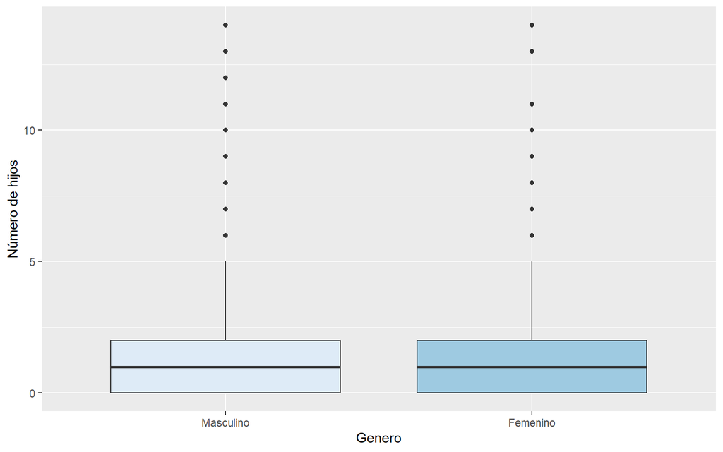

```r
gra1
```

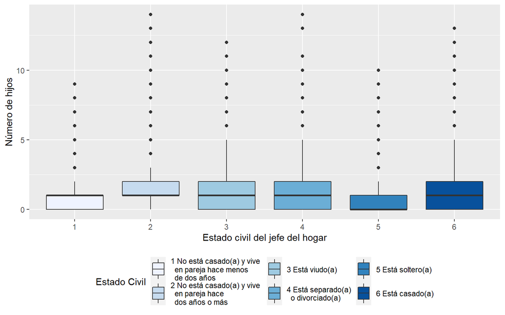

```r
gra2
```

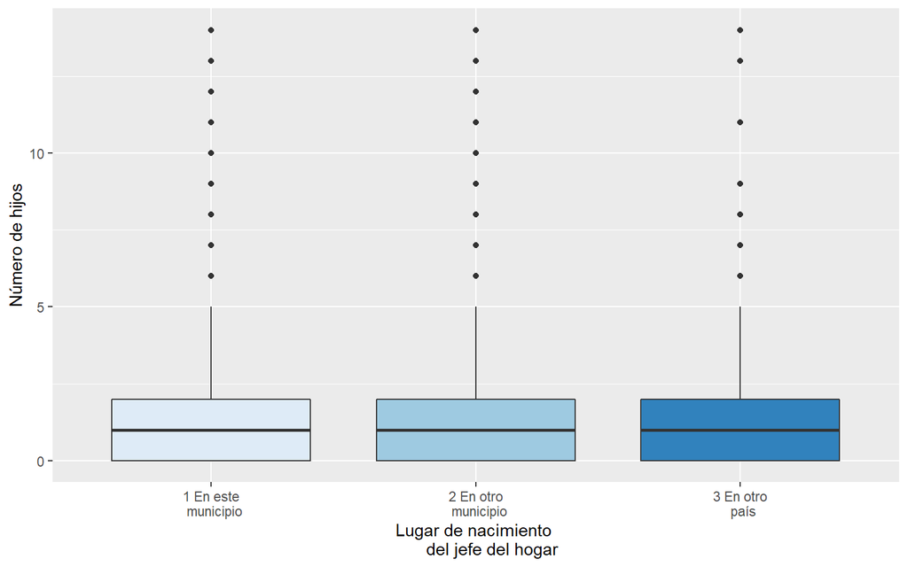

```r
gra3
```

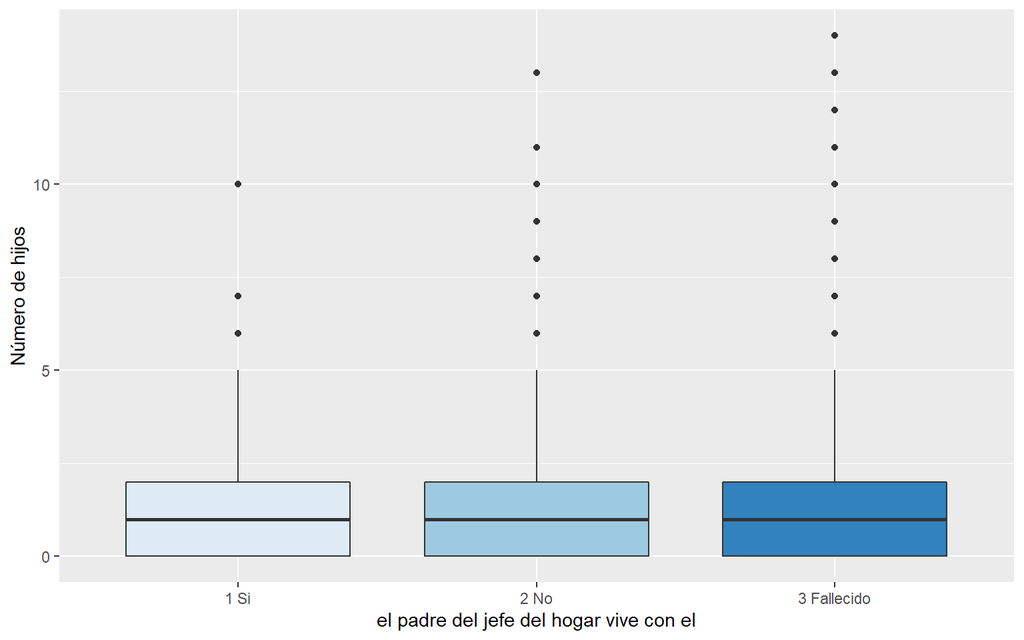

```r
gra4
```

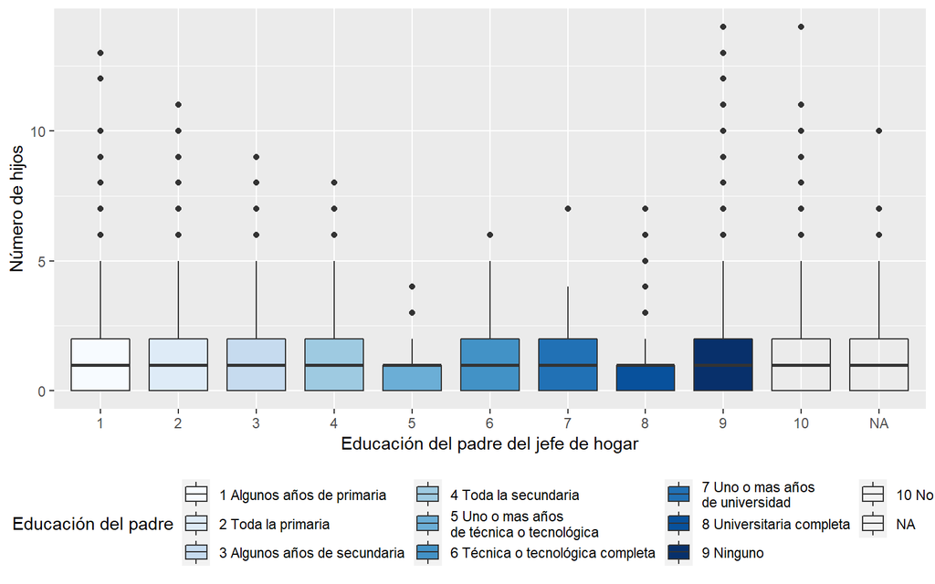

```r
gra5
```

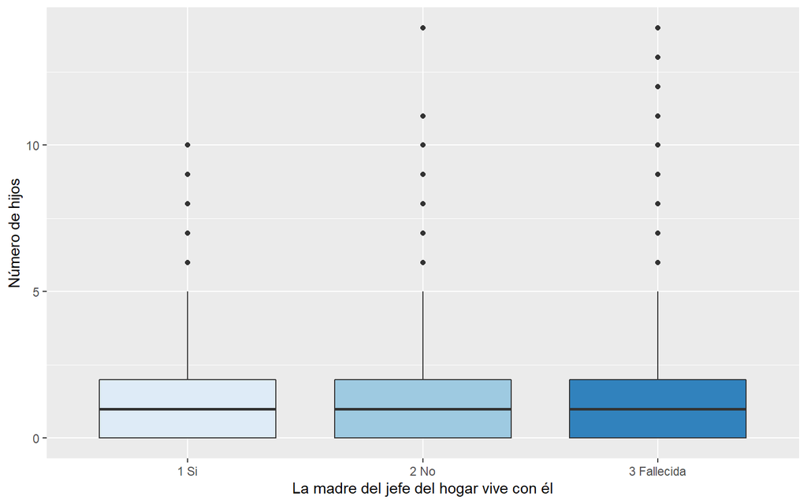

```r
gra6
```

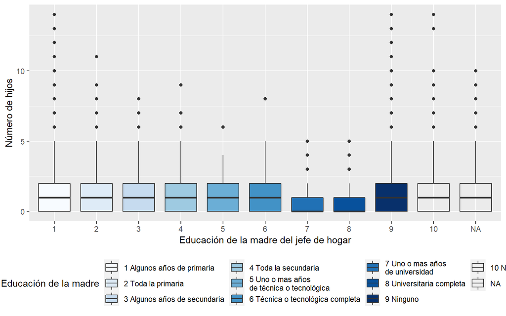

```r
gra7
```

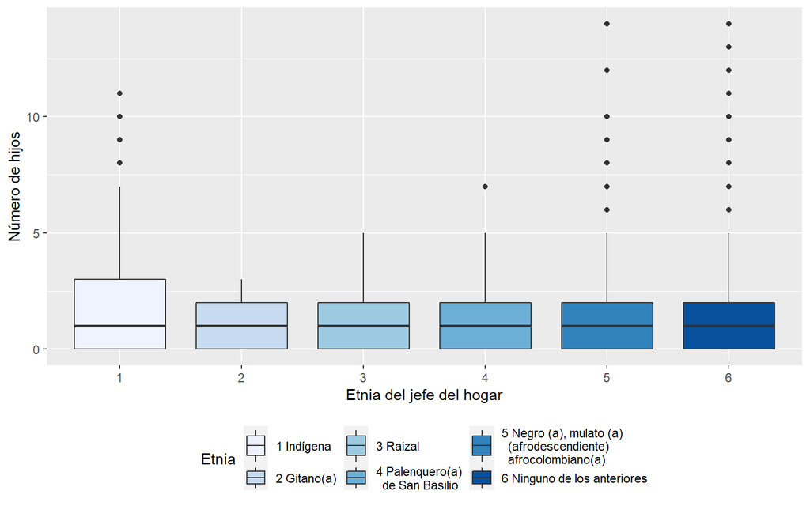

```r
gra8
```

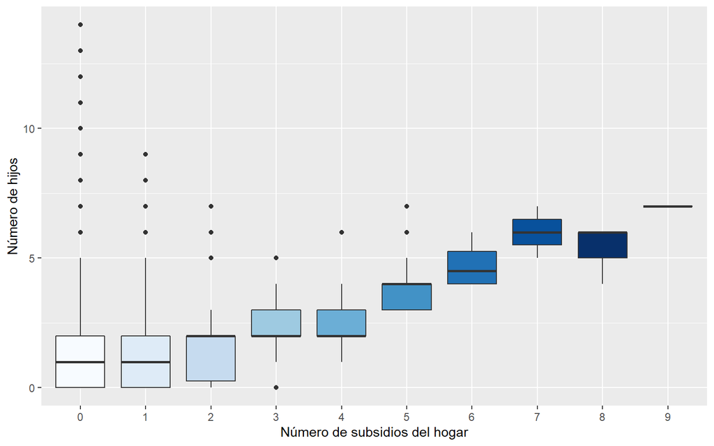

```r
gra9
```

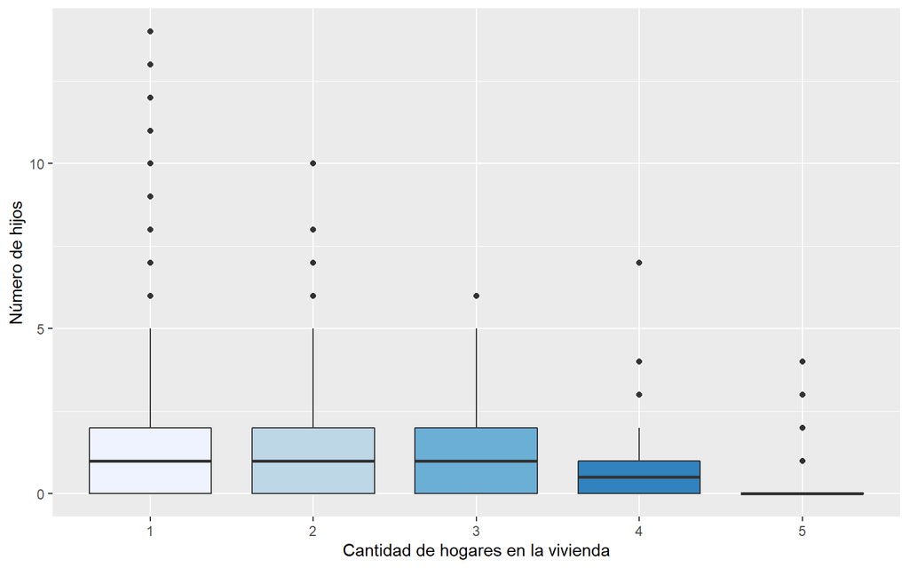

```r
gra10
```

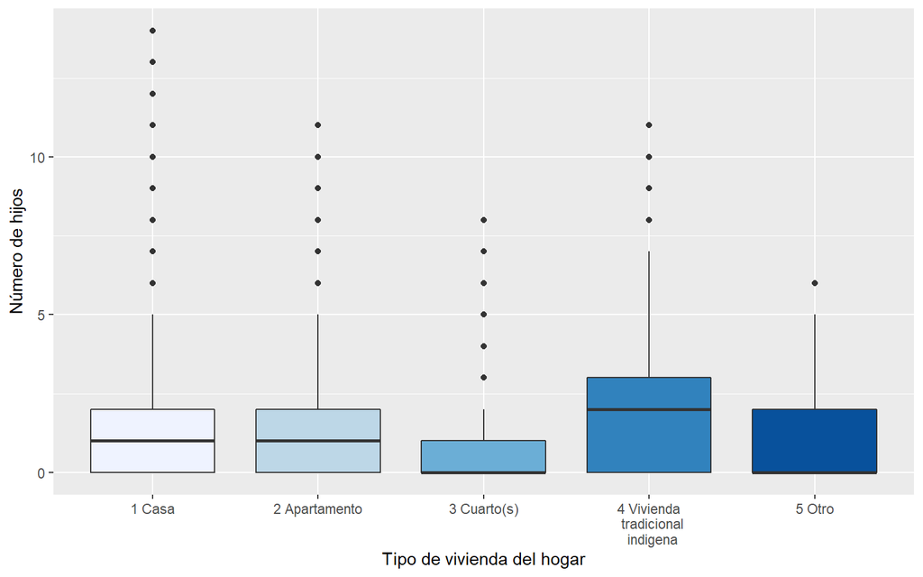

```r
gra11
```

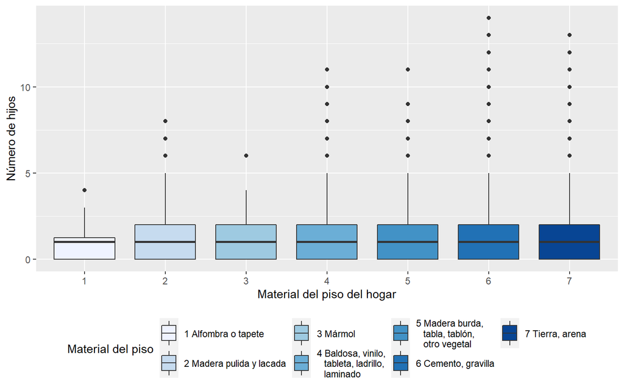

```r
gra12
```

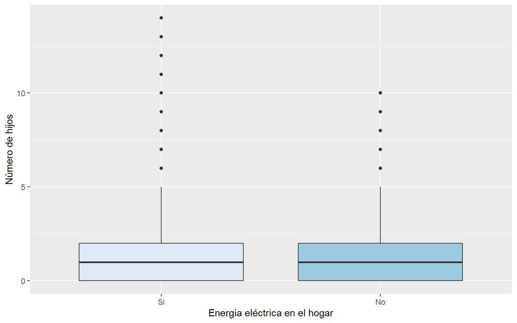

```r
gra13
```

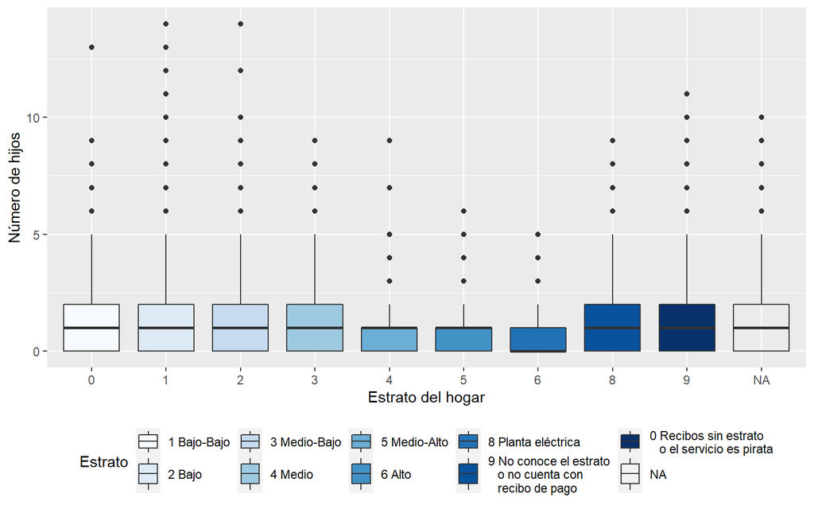

```r
gra14
```

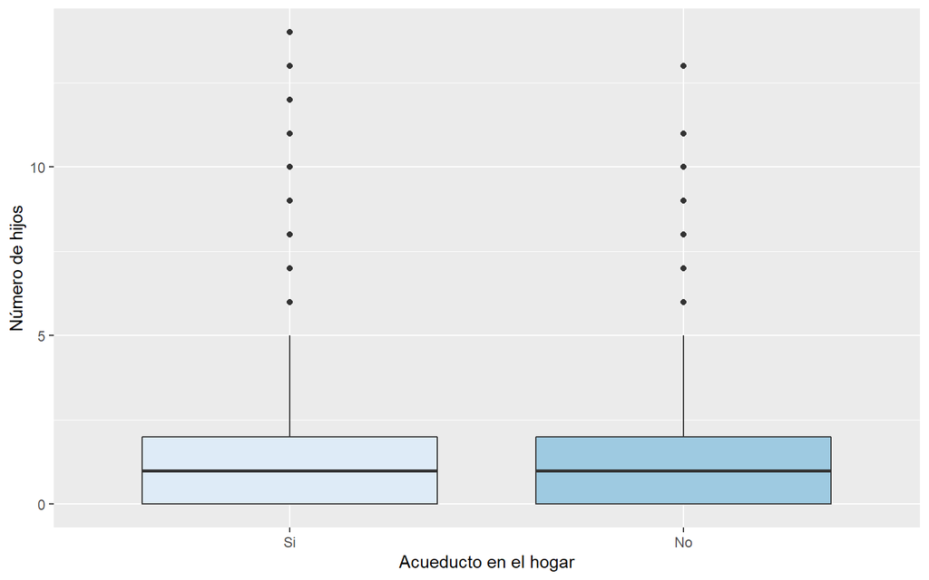

```r
gra15
```

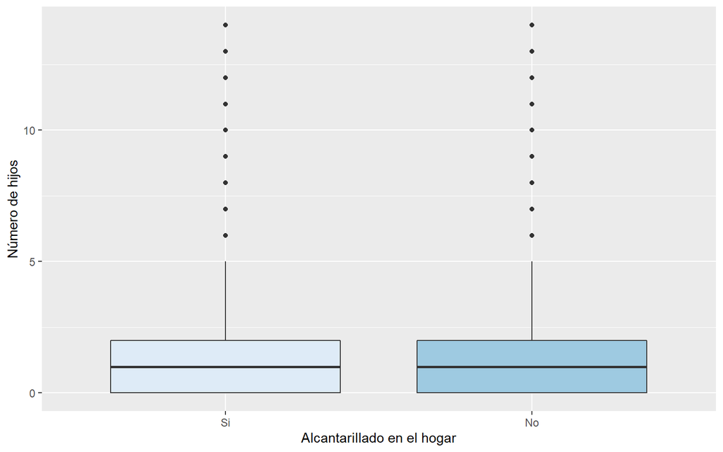

```r
gra16
```

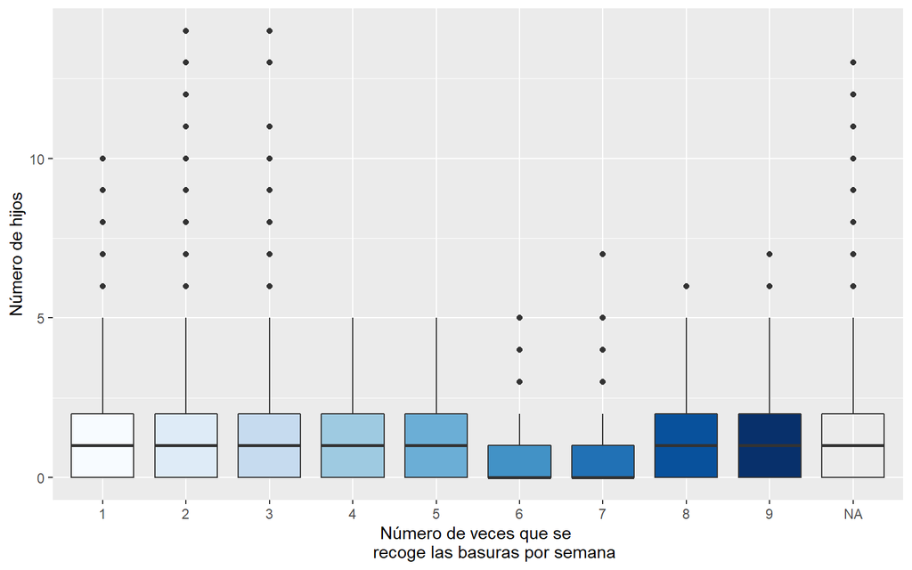

```r
gra17
```

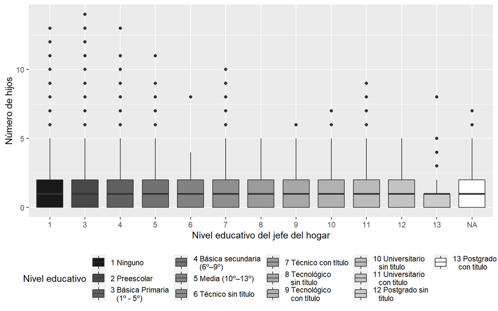

```r
gra18
```

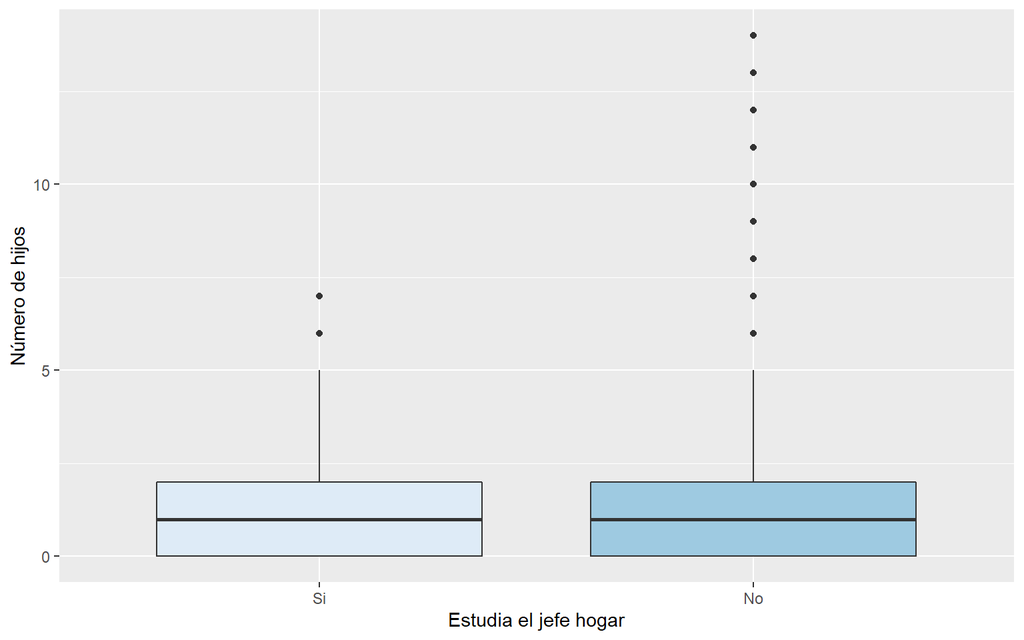

```r
gra19
```

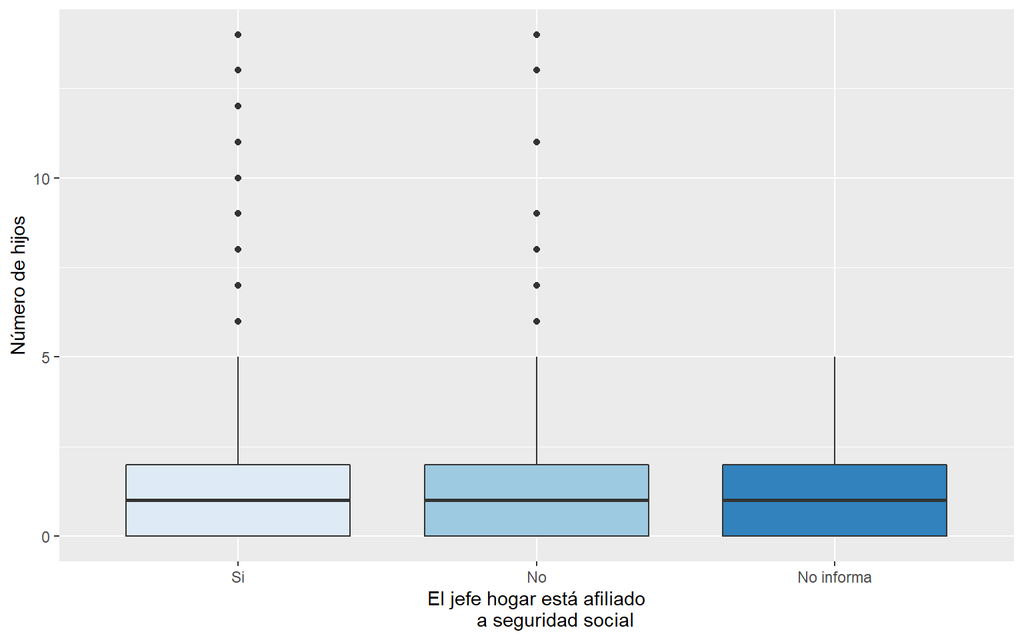

```r
gra20
```

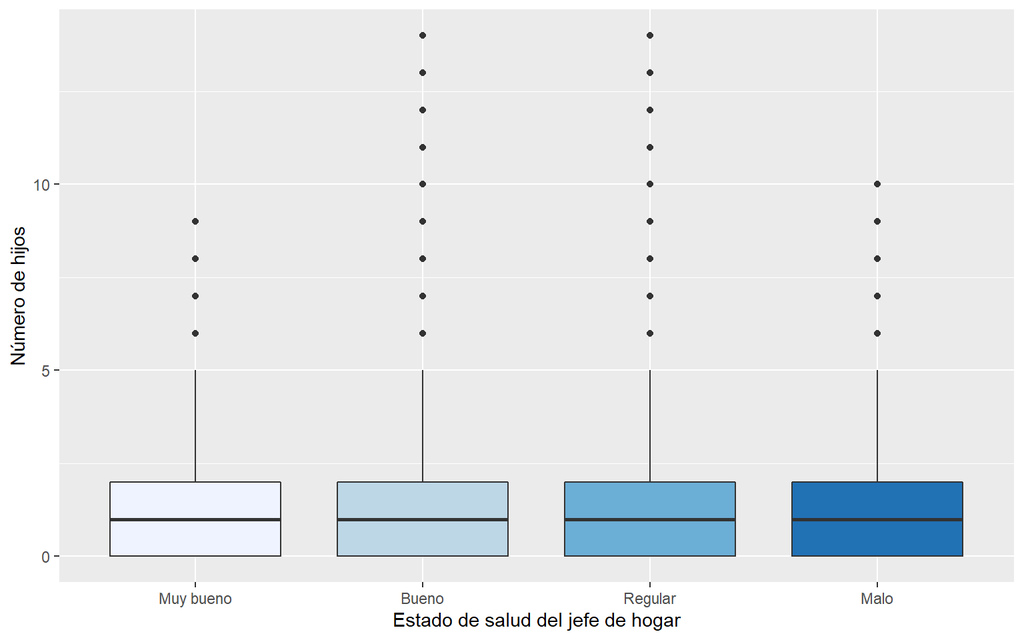

```r
gra21
```

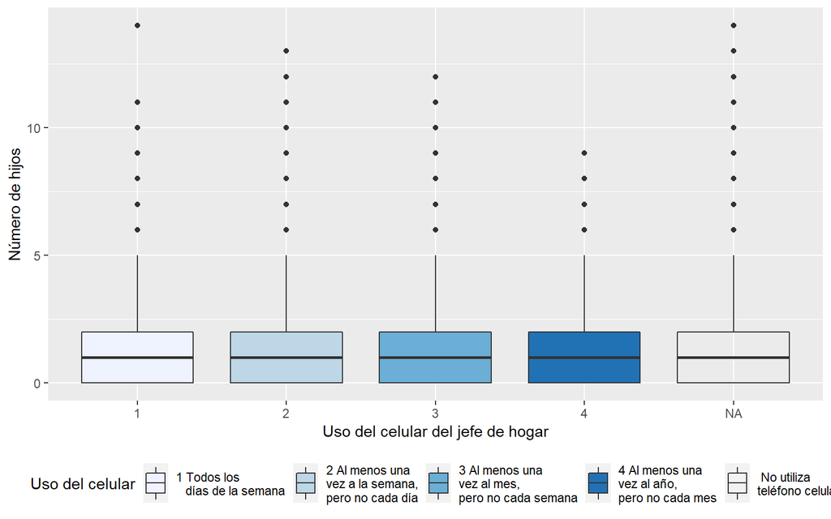

```r
gra22
```

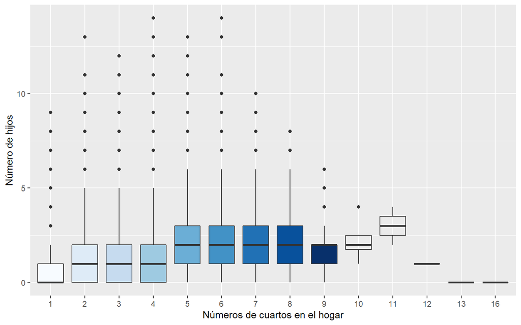

```r
gra23
```

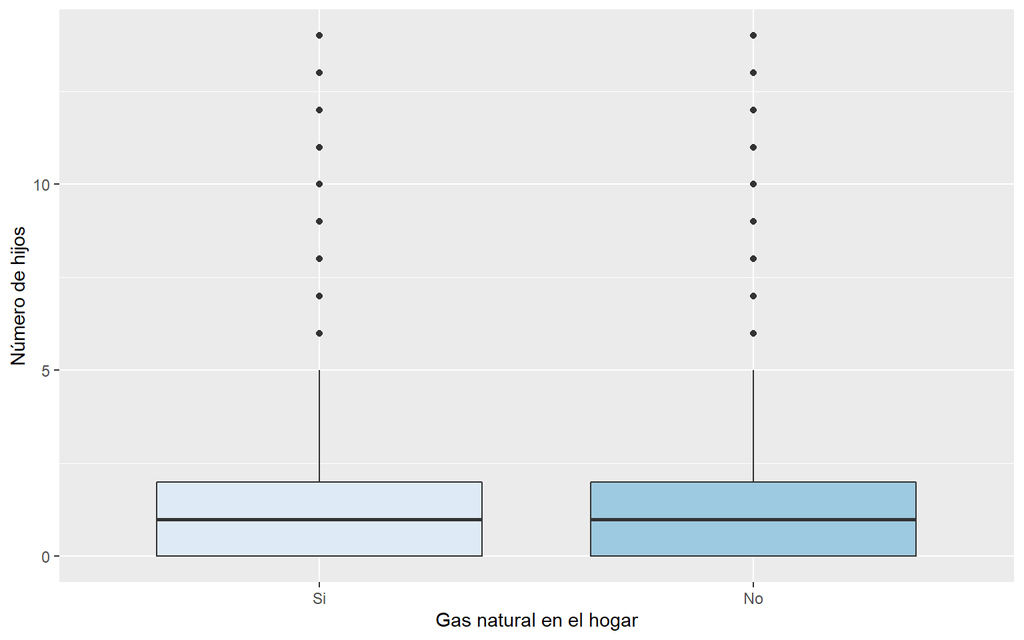

```r
gra24
```

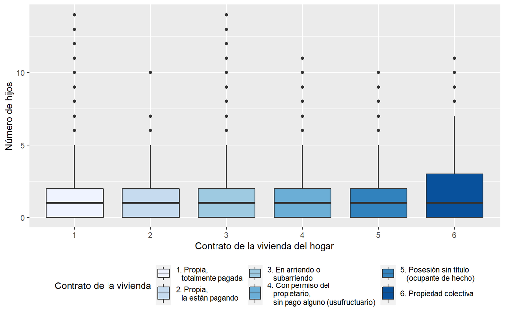

```r
gra25
```

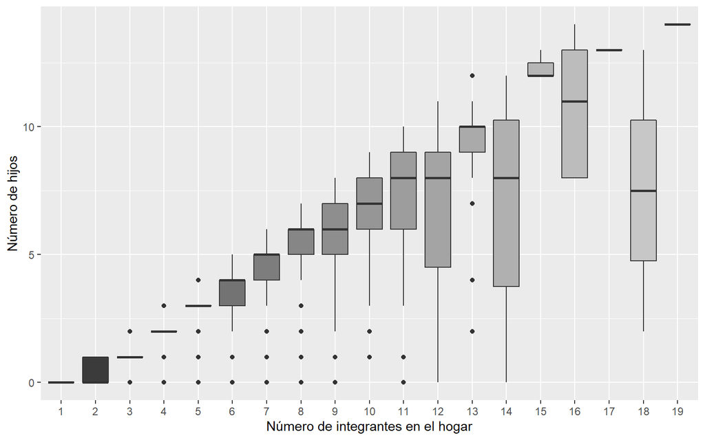

```r
gra26
```

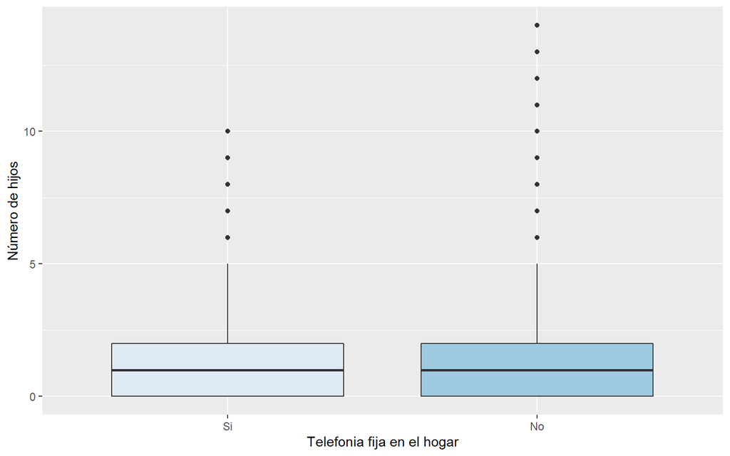

```r
gra27
```

Y para las variables numéricas se utilizan gráficos de puntos vs Num_hijos para analizar la posible influencia o relación de cada predictora con la respuesta.

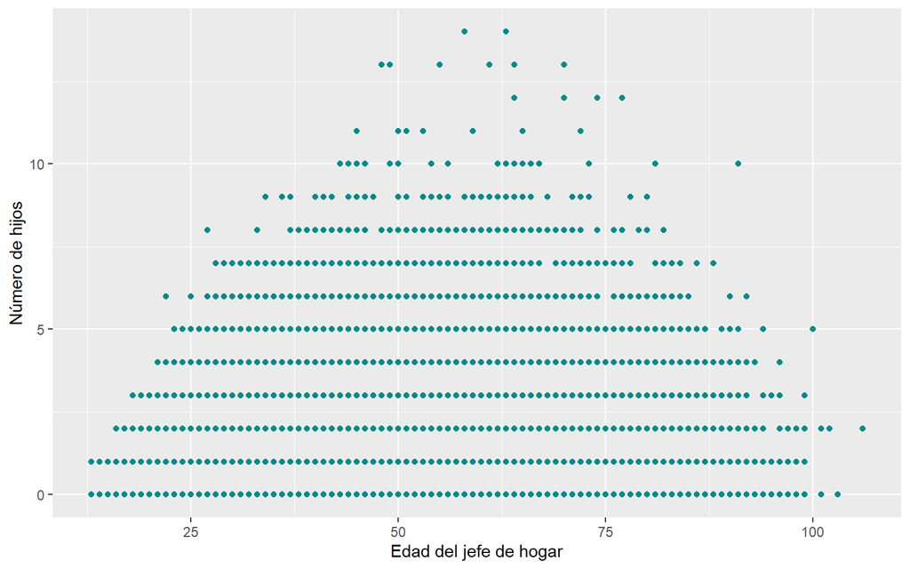

```r
puntos1
```

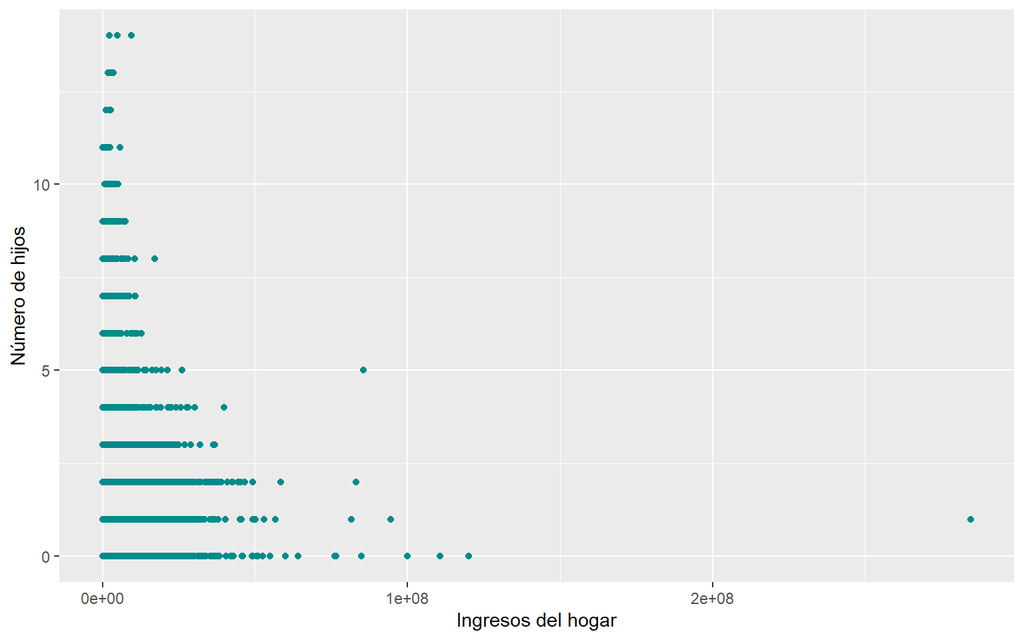

```r
puntos2
```

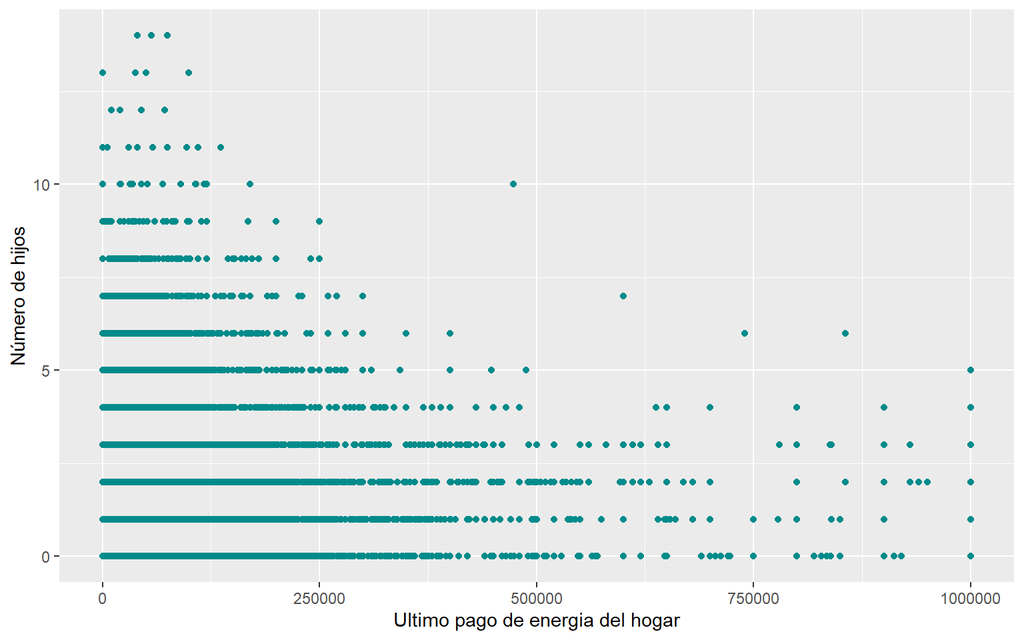

```r
puntos3
```

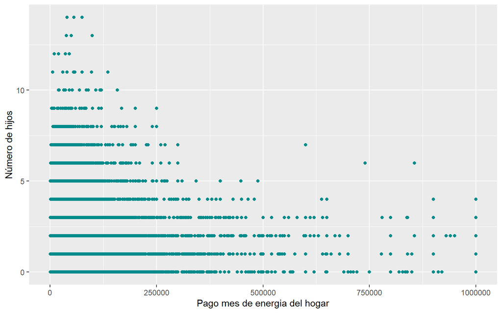

```r
puntos4
```

### Variables escogidas a partir de los graficos descriptivos

| Variables interesantes |
| --- |
| Genero |
| Edad |
| Num_integrantes |
| Num_cuartos |
| Estrato |
| Tipo_vivienda |
| Num_Subsidios |
| Educacion_madre |
| Estado_civil |
| Ultimo_pago_energia |
| Ingresos_hogar |
| Cant_hogares_vivienda |
| Num_hijos |

Se realiza un subset con las variables interesantes

| Genero | Edad | Num_integrantes | Num_cuartos | Estrato | Tipo_vivienda | Num_Subsidios | Educacion_madre | Estado_civil | Ultimo_pago_energia | Ingresos_hogar | Cant_hogares_vivienda | Num_hijos |
| --- | --- | --- | --- | --- | --- | --- | --- | --- | --- | --- | --- | --- |
| 2 | 44 | 4 | 3 | 3 | 2 | 0 | 1 | 2 | 85000 | 3800000.0 | 1 | 1 |
| 1 | 61 | 10 | 5 | 2 | 1 | 0 | 2 | 6 | 62000 | 3656652.8 | 1 | 7 |
| 1 | 79 | 2 | 5 | 3 | 1 | 0 | 10 | 6 | 189000 | 4200000.0 | 1 | 0 |
| 2 | 37 | 3 | 3 | 3 | 2 | 0 | 3 | 5 | 188800 | 1365000.0 | 1 | 0 |
| 1 | 72 | 3 | 4 | 2 | 2 | 0 | 2 | 5 | 87000 | 765833.3 | 1 | 0 |
| 1 | 73 | 1 | 3 | 2 | 2 | 0 | 9 | 5 | 30000 | 1785721.9 | 1 | 0 |

Las variables categóricas de Base_interesante se convierten a factor y se crea un modelo de regresión lineal múltiple para poder utilizar selección de variables por regresión paso a paso.

### Regresión por paso a paso

```r
require(olsrr)

mod1 <- lm(Num_hijos~., data = Base_interesante) # Modelo de regresión lineal múltiple
ols_step_both_p(mod1) # Selección
```

```
##
##                                       Stepwise Selection Summary
## ------------------------------------------------------------------------------------------------------
##                                 Added/                   Adj.
## Step         Variable          Removed     R-Square    R-Square       C(p)           AIC         RMSE
## ------------------------------------------------------------------------------------------------------
##    1      Num_integrantes      addition       0.836       0.836    14121.0890    147987.0388    0.5567
##    2        Num_cuartos        addition       0.838       0.838    12584.9020    146651.7229    0.5525
##    3          Estrato          addition       0.838       0.838    12431.6950    146517.6593    0.5521
##    4       Tipo_vivienda       addition       0.839       0.839    12302.1070    146404.1379    0.5517
##    5       Estado_civil        addition       0.839       0.839    12229.5050    146340.5776    0.5515
##    6          Genero           addition       0.859       0.859        2.3500    131676.5283    0.5171
##    7    Ultimo_pago_energia    addition       0.859       0.859      -10.3360    131663.8376    0.5170
## ------------------------------------------------------------------------------------------------------
```

### Selección de las variables de interés con Lasso

Se toma la Base_final que posee 32 variables y se convierten las variables categóricas a factor. Se eliminan las variables con mayor número de NA y se eliminan las filas con NA, para poder aplicar Lasso.

Se crea una matriz de diseño para aplicar Regresión Lasso

```r
x <- model.matrix(Num_hijos ~ ., Base_menos_Nas)[,-1] # Matriz de diseño
y <- Base_menos_Nas$Num_hijos # Variable respuesta

# Aplicación de la técnica de regularización

require(glmnet)

gridz <- 10^seq(-2,10, length = 100) # Malla de lambdas
lasso.mod <- glmnet(x, y, alpha = 1, lambda = gridz) # Ajuste del modelo
```

Se hace validación cruzada para seleccionar el $\lambda$ óptimo, que se aplicará en el modelo

```r
set.seed(23)

# Indices para las filas del conjunto de entrenamiento
train <- sample(1:nrow(x), nrow(x)/2)

# Indices para las filas del conjunto de test
test <- -train
y.test <- y[test]

# Validación cruzada
cv.out <- cv.glmnet(x[train,], y[train], alpha=1)

# Obtención del mejor lambda
bestlam <-cv.out$lambda.min

# Lasso con el lambda óptimo
out <- glmnet(x, y, alpha=1)
lasso.coef <-predict(out, type = "coefficients", s=bestlam)[1:90, ]
```

A continuación se muestra las variables seleccionadas por medio de los dos métodos anteriores:

| Variables | Regresion por pasos | Lasso |
| --- | --- | --- |
| Genero | X | X |
| Edad |  |  |
| Estado_civil | X | X |
| Lugar_nacimiento |  | X |
| Vive_hogar_padre |  |  |
| Educacion_padre |  |  |
| Vive_hogar_madre |  | X |
| Educacion_madre |  |  |
| Etnia |  | X |
| Num_subsidios |  | X |
| Cant_hogares_vivienda |  |  |
| Tipo_vivienda | X | X |
| Material_pisos |  | X |
| Energia_electrica |  |  |
| Estrato | X |  |
| Acueducto |  |  |
| Alcantarillado |  |  |
| Nivel_educativo |  | X |
| Estudia |  |  |
| Afiliado |  | X |
| Salud_general |  |  |
| Uso_celular |  | X |
| Num_cuartos | X | X |
| Gas_natural |  |  |
| Telefonia_fija |  |  |
| Ingresos_hogar |  |  |
| Contrato_vivienda |  | X |
| Ultimo_pago_energia | X |  |
| Num_integrantes | X |  |

Con los anteriores procesos, se obtiene la siguiente base, que se usará en la parte de modelamiento

| Genero | Edad | Num_integrantes | Num_cuartos | Estrato | Tipo_vivienda | Num_Subsidios | Educacion_madre | Estado_civil | Ultimo_pago_energia | Ingresos_hogar | Cant_hogares_vivienda | Num_hijos | Uso_celular | Vive_hogar_madre | Contrato_vivienda | Etnia | Afiliado | Lugar_nacimiento | Nivel_educativo |
| --- | --- | --- | --- | --- | --- | --- | --- | --- | --- | --- | --- | --- | --- | --- | --- | --- | --- | --- | --- |
| 2 | 44 | 4 | 3 | 3 | 2 | 0 | 1 | 2 | 85000 | 3800000.0 | 1 | 1 | 1 | 3 | 3 | 6 | 1 | 1 | 7 |
| 1 | 61 | 10 | 5 | 2 | 1 | 0 | 2 | 6 | 62000 | 3656652.8 | 1 | 7 | 1 | 3 | 4 | 5 | 1 | 1 | 5 |
| 1 | 79 | 2 | 5 | 3 | 1 | 0 | 10 | 6 | 189000 | 4200000.0 | 1 | 0 | 2 | 3 | 1 | 6 | 1 | 2 | 11 |
| 2 | 37 | 3 | 3 | 3 | 2 | 0 | 3 | 5 | 188800 | 1365000.0 | 1 | 0 | 2 | 2 | 3 | 6 | 1 | 2 | 9 |
| 1 | 72 | 3 | 4 | 2 | 2 | 0 | 2 | 5 | 87000 | 765833.3 | 1 | 0 | NA | 3 | 1 | 5 | 1 | 1 | 4 |
| 1 | 73 | 1 | 3 | 2 | 2 | 0 | 9 | 5 | 30000 | 1785721.9 | 1 | 0 | 1 | 3 | 3 | 6 | 1 | 2 | 3 |